# 汽车价格预测 slides

#### 数据集简介

主要包括3类指标:

- 汽车的各种特性.
- 保险风险评级：(-3, -2, -1, 0, 1, 2, 3).
- 每辆保险车辆年平均相对损失支付.

#### 类别属性

- make: 汽车的商标（奥迪，宝马。。。）
- fuel-type: 汽油还是天然气
- aspiration: 涡轮
- num-of-doors: 两门还是四门
- body-style: 硬顶车、轿车、掀背车、敞篷车
- drive-wheels: 驱动轮
- engine-location: 发动机位置
- engine-type: 发动机类型
- num-of-cylinders: 几个气缸
- fuel-system: 燃油系统

#### 连续指标

- bore: continuous from 2.54 to 3.94.
- stroke: continuous from 2.07 to 4.17.
- compression-ratio: continuous from 7 to 23.
- horsepower: continuous from 48 to 288.
- peak-rpm: continuous from 4150 to 6600.
- city-mpg: continuous from 13 to 49.
- highway-mpg: continuous from 16 to 54.
- price: continuous from 5118 to 45400.

### 数据读取与分析

```python
# loading packages
import numpy as np
import pandas as pd
from pandas import datetime

# data visualization and missing values
import matplotlib.pyplot as plt
import seaborn as sns # advanced vizs
import missingno as msno # 对缺失值进行很好的可视化展示
%matplotlib inline

# stats
from statsmodels.distributions.empirical_distribution import ECDF
from sklearn.metrics import mean_squared_error, r2_score

# machine learning
from sklearn.preprocessing import StandardScaler
from sklearn.linear_model import Lasso, LassoCV
from sklearn.model_selection import train_test_split, cross_val_score
from sklearn.ensemble import RandomForestRegressor
seed = 123

# importing data ( ? = missing values)
data = pd.read_csv("Auto-Data.csv", na_values = '?')
data.columns
```

```
Index(['symboling', 'normalized-losses', 'make', 'fuel-type', 'aspiration',
       'num-of-doors', 'body-style', 'drive-wheels', 'engine-location',
       'wheel-base', 'length', 'width', 'height', 'curb-weight', 'engine-type',
       'num-of-cylinders', 'engine-size', 'fuel-system', 'bore', 'stroke',
       'compression-ratio', 'horsepower', 'peak-rpm', 'city-mpg',
       'highway-mpg', 'price'],
      dtype='object')
```

```python
data.dtypes
```

```
symboling              int64
normalized-losses    float64
make                  object
fuel-type             object
aspiration            object
num-of-doors          object
body-style            object
drive-wheels          object
engine-location       object
wheel-base           float64
length               float64
width                float64
height               float64
curb-weight            int64
engine-type           object
num-of-cylinders      object
engine-size            int64
fuel-system           object
bore                 float64
stroke               float64
compression-ratio    float64
horsepower           float64
peak-rpm             float64
city-mpg               int64
highway-mpg            int64
price                float64
dtype: object
```

```python
# first glance at the data itself
print("In total: ",data.shape)
data.head(5)
```

```
In total:  (205, 26)
```

|  | symboling | normalized-losses | make | fuel-type | aspiration | num-of-doors | body-style | drive-wheels | engine-location | wheel-base | ... | engine-size | fuel-system | bore | stroke | compression-ratio | horsepower | peak-rpm | city-mpg | highway-mpg | price |
| --- | --- | --- | --- | --- | --- | --- | --- | --- | --- | --- | --- | --- | --- | --- | --- | --- | --- | --- | --- | --- | --- |
| 0 | 3 | NaN | alfa-romero | gas | std | two | convertible | rwd | front | 88.6 | ... | 130 | mpfi | 3.47 | 2.68 | 9.0 | 111.0 | 5000.0 | 21 | 27 | 13495.0 |
| 1 | 3 | NaN | alfa-romero | gas | std | two | convertible | rwd | front | 88.6 | ... | 130 | mpfi | 3.47 | 2.68 | 9.0 | 111.0 | 5000.0 | 21 | 27 | 16500.0 |
| 2 | 1 | NaN | alfa-romero | gas | std | two | hatchback | rwd | front | 94.5 | ... | 152 | mpfi | 2.68 | 3.47 | 9.0 | 154.0 | 5000.0 | 19 | 26 | 16500.0 |
| 3 | 2 | 164.0 | audi | gas | std | four | sedan | fwd | front | 99.8 | ... | 109 | mpfi | 3.19 | 3.40 | 10.0 | 102.0 | 5500.0 | 24 | 30 | 13950.0 |
| 4 | 2 | 164.0 | audi | gas | std | four | sedan | 4wd | front | 99.4 | ... | 136 | mpfi | 3.19 | 3.40 | 8.0 | 115.0 | 5500.0 | 18 | 22 | 17450.0 |

5 rows × 26 columns

一个比较小的数据集:只有 205 条数据, 26个特征

```python
data.describe()
```

|  | symboling | normalized-losses | wheel-base | length | width | height | curb-weight | engine-size | bore | stroke | compression-ratio | horsepower | peak-rpm | city-mpg | highway-mpg | price |
| --- | --- | --- | --- | --- | --- | --- | --- | --- | --- | --- | --- | --- | --- | --- | --- | --- |
| count | 205.000000 | 164.000000 | 205.000000 | 205.000000 | 205.000000 | 205.000000 | 205.000000 | 205.000000 | 201.000000 | 201.000000 | 205.000000 | 203.000000 | 203.000000 | 205.000000 | 205.000000 | 201.000000 |
| mean | 0.834146 | 122.000000 | 98.756585 | 174.049268 | 65.907805 | 53.724878 | 2555.565854 | 126.907317 | 3.329751 | 3.255423 | 10.142537 | 104.256158 | 5125.369458 | 25.219512 | 30.751220 | 13207.129353 |
| std | 1.245307 | 35.442168 | 6.021776 | 12.337289 | 2.145204 | 2.443522 | 520.680204 | 41.642693 | 0.273539 | 0.316717 | 3.972040 | 39.714369 | 479.334560 | 6.542142 | 6.886443 | 7947.066342 |
| min | -2.000000 | 65.000000 | 86.600000 | 141.100000 | 60.300000 | 47.800000 | 1488.000000 | 61.000000 | 2.540000 | 2.070000 | 7.000000 | 48.000000 | 4150.000000 | 13.000000 | 16.000000 | 5118.000000 |
| 25% | 0.000000 | 94.000000 | 94.500000 | 166.300000 | 64.100000 | 52.000000 | 2145.000000 | 97.000000 | 3.150000 | 3.110000 | 8.600000 | 70.000000 | 4800.000000 | 19.000000 | 25.000000 | 7775.000000 |
| 50% | 1.000000 | 115.000000 | 97.000000 | 173.200000 | 65.500000 | 54.100000 | 2414.000000 | 120.000000 | 3.310000 | 3.290000 | 9.000000 | 95.000000 | 5200.000000 | 24.000000 | 30.000000 | 10295.000000 |
| 75% | 2.000000 | 150.000000 | 102.400000 | 183.100000 | 66.900000 | 55.500000 | 2935.000000 | 141.000000 | 3.590000 | 3.410000 | 9.400000 | 116.000000 | 5500.000000 | 30.000000 | 34.000000 | 16500.000000 |
| max | 3.000000 | 256.000000 | 120.900000 | 208.100000 | 72.300000 | 59.800000 | 4066.000000 | 326.000000 | 3.940000 | 4.170000 | 23.000000 | 288.000000 | 6600.000000 | 49.000000 | 54.000000 | 45400.000000 |

### 缺失值处理

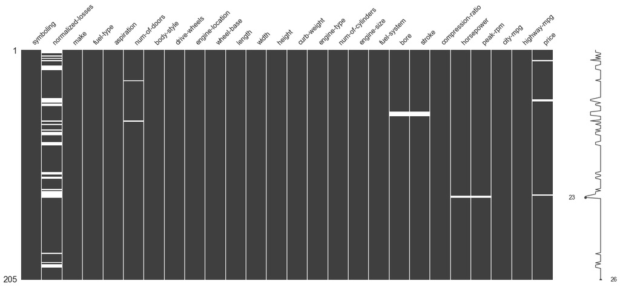

```python
# missing values?
sns.set(style = "ticks")

msno.matrix(data)
#https://github.com/ResidentMario/missingno
```

`normalized-losses` 缺失比较严重

```python
# missing values in normalied-losses
data[pd.isnull(data['normalized-losses'])].head()
```

|  | symboling | normalized-losses | make | fuel-type | aspiration | num-of-doors | body-style | drive-wheels | engine-location | wheel-base | ... | engine-size | fuel-system | bore | stroke | compression-ratio | horsepower | peak-rpm | city-mpg | highway-mpg | price |
| --- | --- | --- | --- | --- | --- | --- | --- | --- | --- | --- | --- | --- | --- | --- | --- | --- | --- | --- | --- | --- | --- |
| 0 | 3 | NaN | alfa-romero | gas | std | two | convertible | rwd | front | 88.6 | ... | 130 | mpfi | 3.47 | 2.68 | 9.0 | 111.0 | 5000.0 | 21 | 27 | 13495.0 |
| 1 | 3 | NaN | alfa-romero | gas | std | two | convertible | rwd | front | 88.6 | ... | 130 | mpfi | 3.47 | 2.68 | 9.0 | 111.0 | 5000.0 | 21 | 27 | 16500.0 |
| 2 | 1 | NaN | alfa-romero | gas | std | two | hatchback | rwd | front | 94.5 | ... | 152 | mpfi | 2.68 | 3.47 | 9.0 | 154.0 | 5000.0 | 19 | 26 | 16500.0 |
| 5 | 2 | NaN | audi | gas | std | two | sedan | fwd | front | 99.8 | ... | 136 | mpfi | 3.19 | 3.40 | 8.5 | 110.0 | 5500.0 | 19 | 25 | 15250.0 |
| 7 | 1 | NaN | audi | gas | std | four | wagon | fwd | front | 105.8 | ... | 136 | mpfi | 3.19 | 3.40 | 8.5 | 110.0 | 5500.0 | 19 | 25 | 18920.0 |

5 rows × 26 columns

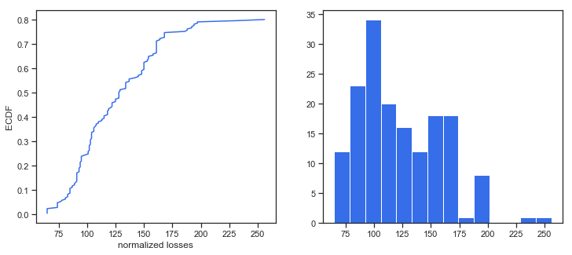

```python
sns.set(style = "ticks")
plt.figure(figsize = (12, 5))
c = '#366DE8'

# ECDF
plt.subplot(121)
cdf = ECDF(data['normalized-losses'])   # 累计连续分布图
plt.plot(cdf.x, cdf.y, label = "statmodels", color = c);
plt.xlabel('normalized losses'); plt.ylabel('ECDF');

# overall distribution
plt.subplot(122)
plt.hist(data['normalized-losses'].dropna(),    # 数据实际分布情况
         bins = int(np.sqrt(len(data['normalized-losses']))),
         color = c);
```

可以发现 **80% 的 normalized losses 是低于200** 并且绝大多数低于125.

一个基本的想法就是用中位数来进行填充，但是需要考虑，这个特征跟哪些因素可能有关呢？应该是保险的情况，所以可以**分组来进行填充**这样会更精确一些。

首先来观测对于不同保险情况的统计指标:

```python
data.groupby('symboling')['normalized-losses'].describe()
```

| symboling | count | mean | std | min | 25% | 50% | 75% | max |
| --- | --- | --- | --- | --- | --- | --- | --- | --- |
| -2 | 3.0 | 103.000000 | 0.000000 | 103.0 | 103.00 | 103.0 | 103.0 | 103.0 |
| -1 | 20.0 | 85.600000 | 18.528499 | 65.0 | 71.75 | 91.5 | 95.0 | 137.0 |
| 0 | 48.0 | 113.166667 | 32.510773 | 77.0 | 91.00 | 102.0 | 120.5 | 192.0 |
| 1 | 47.0 | 128.574468 | 28.478630 | 74.0 | 105.50 | 125.0 | 148.0 | 231.0 |
| 2 | 29.0 | 125.689655 | 30.167513 | 83.0 | 94.00 | 134.0 | 137.0 | 192.0 |
| 3 | 17.0 | 168.647059 | 30.636867 | 142.0 | 150.00 | 150.0 | 194.0 | 256.0 |

```python
# 删除在['price', 'bore', 'stroke'...]等列上有缺失值的数据
data = data.dropna(subset = ['price', 'bore', 'stroke', 'peak-rpm', 'horsepower', 'num-of-doors'])
# ↓拿当前组的均值进行填充
data['normalized-losses'] = data.groupby('symboling')['normalized-losses'].transform(lambda x: x.fillna(x.mean()))

print('In total:', data.shape)
data.head()
```

```
In total: (193, 26)
```

|  | symboling | normalized-losses | make | fuel-type | aspiration | num-of-doors | body-style | drive-wheels | engine-location | wheel-base | ... | engine-size | fuel-system | bore | stroke | compression-ratio | horsepower | peak-rpm | city-mpg | highway-mpg | price |
| --- | --- | --- | --- | --- | --- | --- | --- | --- | --- | --- | --- | --- | --- | --- | --- | --- | --- | --- | --- | --- | --- |
| 0 | 3 | 174.384615 | alfa-romero | gas | std | two | convertible | rwd | front | 88.6 | ... | 130 | mpfi | 3.47 | 2.68 | 9.0 | 111.0 | 5000.0 | 21 | 27 | 13495.0 |
| 1 | 3 | 174.384615 | alfa-romero | gas | std | two | convertible | rwd | front | 88.6 | ... | 130 | mpfi | 3.47 | 2.68 | 9.0 | 111.0 | 5000.0 | 21 | 27 | 16500.0 |
| 2 | 1 | 128.152174 | alfa-romero | gas | std | two | hatchback | rwd | front | 94.5 | ... | 152 | mpfi | 2.68 | 3.47 | 9.0 | 154.0 | 5000.0 | 19 | 26 | 16500.0 |
| 3 | 2 | 164.000000 | audi | gas | std | four | sedan | fwd | front | 99.8 | ... | 109 | mpfi | 3.19 | 3.40 | 10.0 | 102.0 | 5500.0 | 24 | 30 | 13950.0 |
| 4 | 2 | 164.000000 | audi | gas | std | four | sedan | 4wd | front | 99.4 | ... | 136 | mpfi | 3.19 | 3.40 | 8.0 | 115.0 | 5500.0 | 18 | 22 | 17450.0 |

5 rows × 26 columns

### 特征相关性

```python
cormatrix = data.corr()
cormatrix
```

|  | symboling | normalized-losses | wheel-base | length | width | height | curb-weight | engine-size | bore | stroke | compression-ratio | horsepower | peak-rpm | city-mpg | highway-mpg | price |
| --- | --- | --- | --- | --- | --- | --- | --- | --- | --- | --- | --- | --- | --- | --- | --- | --- |
| symboling | 1.000000 | 0.593658 | -0.536516 | -0.363194 | -0.247741 | -0.517803 | -0.231086 | -0.068327 | -0.144785 | -0.010884 | -0.175160 | 0.069491 | 0.227899 | 0.017639 | 0.085775 | -0.084835 |
| normalized-losses | 0.593658 | 1.000000 | -0.167286 | -0.038857 | 0.034178 | -0.445925 | 0.085758 | 0.152544 | 0.032765 | 0.057834 | -0.149620 | 0.277376 | 0.245497 | -0.245313 | -0.189911 | 0.160602 |
| wheel-base | -0.536516 | -0.167286 | 1.000000 | 0.879307 | 0.818465 | 0.591239 | 0.782173 | 0.568375 | 0.495957 | 0.174225 | 0.252234 | 0.377040 | -0.350823 | -0.504499 | -0.571771 | 0.584951 |
| length | -0.363194 | -0.038857 | 0.879307 | 1.000000 | 0.857368 | 0.491050 | 0.882694 | 0.686998 | 0.606373 | 0.121888 | 0.156061 | 0.589650 | -0.276144 | -0.702143 | -0.731264 | 0.695928 |
| width | -0.247741 | 0.034178 | 0.818465 | 0.857368 | 1.000000 | 0.310640 | 0.867640 | 0.739903 | 0.541633 | 0.188733 | 0.188631 | 0.621532 | -0.247612 | -0.657153 | -0.702009 | 0.754649 |
| height | -0.517803 | -0.445925 | 0.591239 | 0.491050 | 0.310640 | 1.000000 | 0.305837 | 0.026906 | 0.182445 | -0.054338 | 0.253934 | -0.081730 | -0.257334 | -0.111166 | -0.159850 | 0.136234 |
| curb-weight | -0.231086 | 0.085758 | 0.782173 | 0.882694 | 0.867640 | 0.305837 | 1.000000 | 0.857188 | 0.645070 | 0.175349 | 0.161030 | 0.762154 | -0.278528 | -0.777763 | -0.818104 | 0.835368 |
| engine-size | -0.068327 | 0.152544 | 0.568375 | 0.686998 | 0.739903 | 0.026906 | 0.857188 | 1.000000 | 0.581854 | 0.214518 | 0.025257 | 0.845325 | -0.217769 | -0.716378 | -0.737531 | 0.888778 |
| bore | -0.144785 | 0.032765 | 0.495957 | 0.606373 | 0.541633 | 0.182445 | 0.645070 | 0.581854 | 1.000000 | -0.065038 | -0.004172 | 0.572972 | -0.273766 | -0.601369 | -0.608804 | 0.546295 |
| stroke | -0.010884 | 0.057834 | 0.174225 | 0.121888 | 0.188733 | -0.054338 | 0.175349 | 0.214518 | -0.065038 | 1.000000 | 0.199600 | 0.102913 | -0.068420 | -0.031248 | -0.040274 | 0.096007 |
| compression-ratio | -0.175160 | -0.149620 | 0.252234 | 0.156061 | 0.188631 | 0.253934 | 0.161030 | 0.025257 | -0.004172 | 0.199600 | 1.000000 | -0.203818 | -0.439741 | 0.314648 | 0.249669 | 0.074483 |
| horsepower | 0.069491 | 0.277376 | 0.377040 | 0.589650 | 0.621532 | -0.081730 | 0.762154 | 0.845325 | 0.572972 | 0.102913 | -0.203818 | 1.000000 | 0.101383 | -0.833615 | -0.812078 | 0.812453 |
| peak-rpm | 0.227899 | 0.245497 | -0.350823 | -0.276144 | -0.247612 | -0.257334 | -0.278528 | -0.217769 | -0.273766 | -0.068420 | -0.439741 | 0.101383 | 1.000000 | -0.061032 | -0.008412 | -0.103835 |
| city-mpg | 0.017639 | -0.245313 | -0.504499 | -0.702143 | -0.657153 | -0.111166 | -0.777763 | -0.716378 | -0.601369 | -0.031248 | 0.314648 | -0.833615 | -0.061032 | 1.000000 | 0.971975 | -0.706618 |
| highway-mpg | 0.085775 | -0.189911 | -0.571771 | -0.731264 | -0.702009 | -0.159850 | -0.818104 | -0.737531 | -0.608804 | -0.040274 | 0.249669 | -0.812078 | -0.008412 | 0.971975 | 1.000000 | -0.719178 |
| price | -0.084835 | 0.160602 | 0.584951 | 0.695928 | 0.754649 | 0.136234 | 0.835368 | 0.888778 | 0.546295 | 0.096007 | 0.074483 | 0.812453 | -0.103835 | -0.706618 | -0.719178 | 1.000000 |

```python
#返回函数的上三角矩阵，并且把对角线上的置0，让他们不是最高的。
cormatrix *= np.tri(*cormatrix.values.shape, k=-1).T
cormatrix
```

|  | symboling | normalized-losses | wheel-base | length | width | height | curb-weight | engine-size | bore | stroke | compression-ratio | horsepower | peak-rpm | city-mpg | highway-mpg | price |
| --- | --- | --- | --- | --- | --- | --- | --- | --- | --- | --- | --- | --- | --- | --- | --- | --- |
| symboling | 0.0 | 0.593658 | -0.536516 | -0.363194 | -0.247741 | -0.517803 | -0.231086 | -0.068327 | -0.144785 | -0.010884 | -0.175160 | 0.069491 | 0.227899 | 0.017639 | 0.085775 | -0.084835 |
| normalized-losses | 0.0 | 0.000000 | -0.167286 | -0.038857 | 0.034178 | -0.445925 | 0.085758 | 0.152544 | 0.032765 | 0.057834 | -0.149620 | 0.277376 | 0.245497 | -0.245313 | -0.189911 | 0.160602 |
| wheel-base | -0.0 | -0.000000 | 0.000000 | 0.879307 | 0.818465 | 0.591239 | 0.782173 | 0.568375 | 0.495957 | 0.174225 | 0.252234 | 0.377040 | -0.350823 | -0.504499 | -0.571771 | 0.584951 |
| length | -0.0 | -0.000000 | 0.000000 | 0.000000 | 0.857368 | 0.491050 | 0.882694 | 0.686998 | 0.606373 | 0.121888 | 0.156061 | 0.589650 | -0.276144 | -0.702143 | -0.731264 | 0.695928 |
| width | -0.0 | 0.000000 | 0.000000 | 0.000000 | 0.000000 | 0.310640 | 0.867640 | 0.739903 | 0.541633 | 0.188733 | 0.188631 | 0.621532 | -0.247612 | -0.657153 | -0.702009 | 0.754649 |
| height | -0.0 | -0.000000 | 0.000000 | 0.000000 | 0.000000 | 0.000000 | 0.305837 | 0.026906 | 0.182445 | -0.054338 | 0.253934 | -0.081730 | -0.257334 | -0.111166 | -0.159850 | 0.136234 |
| curb-weight | -0.0 | 0.000000 | 0.000000 | 0.000000 | 0.000000 | 0.000000 | 0.000000 | 0.857188 | 0.645070 | 0.175349 | 0.161030 | 0.762154 | -0.278528 | -0.777763 | -0.818104 | 0.835368 |
| engine-size | -0.0 | 0.000000 | 0.000000 | 0.000000 | 0.000000 | 0.000000 | 0.000000 | 0.000000 | 0.581854 | 0.214518 | 0.025257 | 0.845325 | -0.217769 | -0.716378 | -0.737531 | 0.888778 |
| bore | -0.0 | 0.000000 | 0.000000 | 0.000000 | 0.000000 | 0.000000 | 0.000000 | 0.000000 | 0.000000 | -0.065038 | -0.004172 | 0.572972 | -0.273766 | -0.601369 | -0.608804 | 0.546295 |
| stroke | -0.0 | 0.000000 | 0.000000 | 0.000000 | 0.000000 | -0.000000 | 0.000000 | 0.000000 | -0.000000 | 0.000000 | 0.199600 | 0.102913 | -0.068420 | -0.031248 | -0.040274 | 0.096007 |
| compression-ratio | -0.0 | -0.000000 | 0.000000 | 0.000000 | 0.000000 | 0.000000 | 0.000000 | 0.000000 | -0.000000 | 0.000000 | 0.000000 | -0.203818 | -0.439741 | 0.314648 | 0.249669 | 0.074483 |
| horsepower | 0.0 | 0.000000 | 0.000000 | 0.000000 | 0.000000 | -0.000000 | 0.000000 | 0.000000 | 0.000000 | 0.000000 | -0.000000 | 0.000000 | 0.101383 | -0.833615 | -0.812078 | 0.812453 |
| peak-rpm | 0.0 | 0.000000 | -0.000000 | -0.000000 | -0.000000 | -0.000000 | -0.000000 | -0.000000 | -0.000000 | -0.000000 | -0.000000 | 0.000000 | 0.000000 | -0.061032 | -0.008412 | -0.103835 |
| city-mpg | 0.0 | -0.000000 | -0.000000 | -0.000000 | -0.000000 | -0.000000 | -0.000000 | -0.000000 | -0.000000 | -0.000000 | 0.000000 | -0.000000 | -0.000000 | 0.000000 | 0.971975 | -0.706618 |
| highway-mpg | 0.0 | -0.000000 | -0.000000 | -0.000000 | -0.000000 | -0.000000 | -0.000000 | -0.000000 | -0.000000 | -0.000000 | 0.000000 | -0.000000 | -0.000000 | 0.000000 | 0.000000 | -0.719178 |
| price | -0.0 | 0.000000 | 0.000000 | 0.000000 | 0.000000 | 0.000000 | 0.000000 | 0.000000 | 0.000000 | 0.000000 | 0.000000 | 0.000000 | -0.000000 | -0.000000 | -0.000000 | 0.000000 |

```python
# 整合某一指标与其它指标对应情况,相当于将上表进行一个按照行的所有指标进行列堆叠
cormatrix = cormatrix.stack()
cormatrix
```

```
symboling          symboling            0.000000
                   normalized-losses    0.593658
                   wheel-base          -0.536516
                   length              -0.363194
                   width               -0.247741
                   height              -0.517803
                   curb-weight         -0.231086
                   engine-size         -0.068327
                   bore                -0.144785
                   stroke              -0.010884
                   compression-ratio   -0.175160
                   horsepower           0.069491
                   peak-rpm             0.227899
                   city-mpg             0.017639
                   highway-mpg          0.085775
                   price               -0.084835
normalized-losses  symboling            0.000000
                   normalized-losses    0.000000
                   wheel-base          -0.167286
                   length              -0.038857
                   width                0.034178
                   height              -0.445925
                   curb-weight          0.085758
                   engine-size          0.152544
                   bore                 0.032765
                   stroke               0.057834
                   compression-ratio   -0.149620
                   horsepower           0.277376
                   peak-rpm             0.245497
                   city-mpg            -0.245313
                                          ...
highway-mpg        wheel-base          -0.000000
                   length              -0.000000
                   width               -0.000000
                   height              -0.000000
                   curb-weight         -0.000000
                   engine-size         -0.000000
                   bore                -0.000000
                   stroke              -0.000000
                   compression-ratio    0.000000
                   horsepower          -0.000000
                   peak-rpm            -0.000000
                   city-mpg             0.000000
                   highway-mpg          0.000000
                   price               -0.719178
price              symboling           -0.000000
                   normalized-losses    0.000000
                   wheel-base           0.000000
                   length               0.000000
                   width                0.000000
                   height               0.000000
                   curb-weight          0.000000
                   engine-size          0.000000
                   bore                 0.000000
                   stroke               0.000000
                   compression-ratio    0.000000
                   horsepower           0.000000
                   peak-rpm            -0.000000
                   city-mpg            -0.000000
                   highway-mpg         -0.000000
                   price                0.000000
Length: 256, dtype: float64
```

```python
# 按照相关性从大到小进行排序，第三列为相关系数
cormatrix = cormatrix.reindex(cormatrix.abs().sort_values(ascending=False).index).reset_index()
cormatrix
```

|  | level_0 | level_1 | 0 |
| --- | --- | --- | --- |
| 0 | city-mpg | highway-mpg | 0.971975 |
| 1 | engine-size | price | 0.888778 |
| 2 | length | curb-weight | 0.882694 |
| 3 | wheel-base | length | 0.879307 |
| 4 | width | curb-weight | 0.867640 |
| 5 | length | width | 0.857368 |
| 6 | curb-weight | engine-size | 0.857188 |
| 7 | engine-size | horsepower | 0.845325 |
| 8 | curb-weight | price | 0.835368 |
| 9 | horsepower | city-mpg | -0.833615 |
| 10 | wheel-base | width | 0.818465 |
| 11 | curb-weight | highway-mpg | -0.818104 |
| 12 | horsepower | price | 0.812453 |
| 13 | horsepower | highway-mpg | -0.812078 |
| 14 | wheel-base | curb-weight | 0.782173 |
| 15 | curb-weight | city-mpg | -0.777763 |
| 16 | curb-weight | horsepower | 0.762154 |
| 17 | width | price | 0.754649 |
| 18 | width | engine-size | 0.739903 |
| 19 | engine-size | highway-mpg | -0.737531 |
| 20 | length | highway-mpg | -0.731264 |
| 21 | highway-mpg | price | -0.719178 |
| 22 | engine-size | city-mpg | -0.716378 |
| 23 | city-mpg | price | -0.706618 |
| 24 | length | city-mpg | -0.702143 |
| 25 | width | highway-mpg | -0.702009 |
| 26 | length | price | 0.695928 |
| 27 | length | engine-size | 0.686998 |
| 28 | width | city-mpg | -0.657153 |
| 29 | curb-weight | bore | 0.645070 |
| ... | ... | ... | ... |
| 226 | engine-size | length | 0.000000 |
| 227 | engine-size | wheel-base | 0.000000 |
| 228 | stroke | engine-size | 0.000000 |
| 229 | stroke | stroke | 0.000000 |
| 230 | peak-rpm | normalized-losses | 0.000000 |
| 231 | compression-ratio | symboling | -0.000000 |
| 232 | peak-rpm | symboling | 0.000000 |
| 233 | horsepower | horsepower | 0.000000 |
| 234 | horsepower | compression-ratio | -0.000000 |
| 235 | horsepower | stroke | 0.000000 |
| 236 | horsepower | bore | 0.000000 |
| 237 | horsepower | engine-size | 0.000000 |
| 238 | horsepower | curb-weight | 0.000000 |
| 239 | horsepower | height | -0.000000 |
| 240 | horsepower | width | 0.000000 |
| 241 | horsepower | length | 0.000000 |
| 242 | horsepower | wheel-base | 0.000000 |
| 243 | horsepower | normalized-losses | 0.000000 |
| 244 | horsepower | symboling | 0.000000 |
| 245 | compression-ratio | compression-ratio | 0.000000 |
| 246 | compression-ratio | stroke | 0.000000 |
| 247 | compression-ratio | bore | -0.000000 |
| 248 | compression-ratio | engine-size | 0.000000 |
| 249 | compression-ratio | curb-weight | 0.000000 |
| 250 | compression-ratio | height | 0.000000 |
| 251 | compression-ratio | width | 0.000000 |
| 252 | compression-ratio | length | 0.000000 |
| 253 | compression-ratio | wheel-base | 0.000000 |
| 254 | compression-ratio | normalized-losses | -0.000000 |
| 255 | symboling | symboling | 0.000000 |

256 rows × 3 columns

```python
cormatrix.columns = ["FirstVariable", "SecondVariable", "Correlation"]
cormatrix.head(10)
```

|  | FirstVariable | SecondVariable | Correlation |
| --- | --- | --- | --- |
| 0 | city-mpg | highway-mpg | 0.971975 |
| 1 | engine-size | price | 0.888778 |
| 2 | length | curb-weight | 0.882694 |
| 3 | wheel-base | length | 0.879307 |
| 4 | width | curb-weight | 0.867640 |
| 5 | length | width | 0.857368 |
| 6 | curb-weight | engine-size | 0.857188 |
| 7 | engine-size | horsepower | 0.845325 |
| 8 | curb-weight | price | 0.835368 |
| 9 | horsepower | city-mpg | -0.833615 |

可以观察到 **`city_mpg` 和 `highway-mpg` 这两个差不多是一个意思了**. （解决多重共线性问题）

对于length和width和height，他们应该存在某种配对关系（解决多重共线性问题）

```python
data['volume'] = data.length * data.width * data.height

# 上表观察到curb-weight与length和weight也有很强相关性，因此也要drop掉
data.drop(['width', 'length', 'height',
           'curb-weight', 'city-mpg'],
          axis = 1, # 1 for columns
          inplace = True)
```

```python
# new variables
data.columns
```

```
Index(['symboling', 'normalized-losses', 'make', 'fuel-type', 'aspiration',
       'num-of-doors', 'body-style', 'drive-wheels', 'engine-location',
       'wheel-base', 'engine-type', 'num-of-cylinders', 'engine-size',
       'fuel-system', 'bore', 'stroke', 'compression-ratio', 'horsepower',
       'peak-rpm', 'highway-mpg', 'price', 'volume'],
      dtype='object')
```

将相关图直接画出来

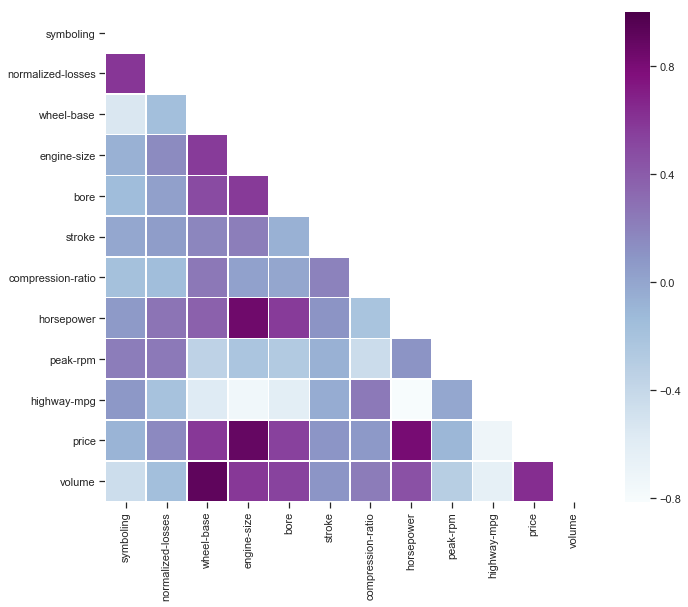

```python
# Compute the correlation matrix
corr_all = data.corr()

# Generate a mask for the upper triangle
mask = np.zeros_like(corr_all, dtype = np.bool)
mask[np.triu_indices_from(mask)] = True

# Set up the matplotlib figure
f, ax = plt.subplots(figsize = (11, 9))

# Draw the heatmap with the mask and correct aspect ratio
sns.heatmap(corr_all, mask = mask,
            square = True, linewidths = .5, ax = ax, cmap = "BuPu")
plt.show()
```

看起来 `price` 跟这几个的相关程度比较大 `wheel-base`,`enginine-size`, `bore`,`horsepower`.

```python
data.head()
```

|  | symboling | normalized-losses | make | fuel-type | aspiration | num-of-doors | body-style | drive-wheels | engine-location | wheel-base | ... | engine-size | fuel-system | bore | stroke | compression-ratio | horsepower | peak-rpm | highway-mpg | price | volume |
| --- | --- | --- | --- | --- | --- | --- | --- | --- | --- | --- | --- | --- | --- | --- | --- | --- | --- | --- | --- | --- | --- |
| 0 | 3 | 174.384615 | alfa-romero | gas | std | two | convertible | rwd | front | 88.6 | ... | 130 | mpfi | 3.47 | 2.68 | 9.0 | 111.0 | 5000.0 | 27 | 13495.0 | 528019.904 |
| 1 | 3 | 174.384615 | alfa-romero | gas | std | two | convertible | rwd | front | 88.6 | ... | 130 | mpfi | 3.47 | 2.68 | 9.0 | 111.0 | 5000.0 | 27 | 16500.0 | 528019.904 |
| 2 | 1 | 128.152174 | alfa-romero | gas | std | two | hatchback | rwd | front | 94.5 | ... | 152 | mpfi | 2.68 | 3.47 | 9.0 | 154.0 | 5000.0 | 26 | 16500.0 | 587592.640 |
| 3 | 2 | 164.000000 | audi | gas | std | four | sedan | fwd | front | 99.8 | ... | 109 | mpfi | 3.19 | 3.40 | 10.0 | 102.0 | 5500.0 | 30 | 13950.0 | 634816.956 |
| 4 | 2 | 164.000000 | audi | gas | std | four | sedan | 4wd | front | 99.4 | ... | 136 | mpfi | 3.19 | 3.40 | 8.0 | 115.0 | 5500.0 | 22 | 17450.0 | 636734.832 |

5 rows × 22 columns

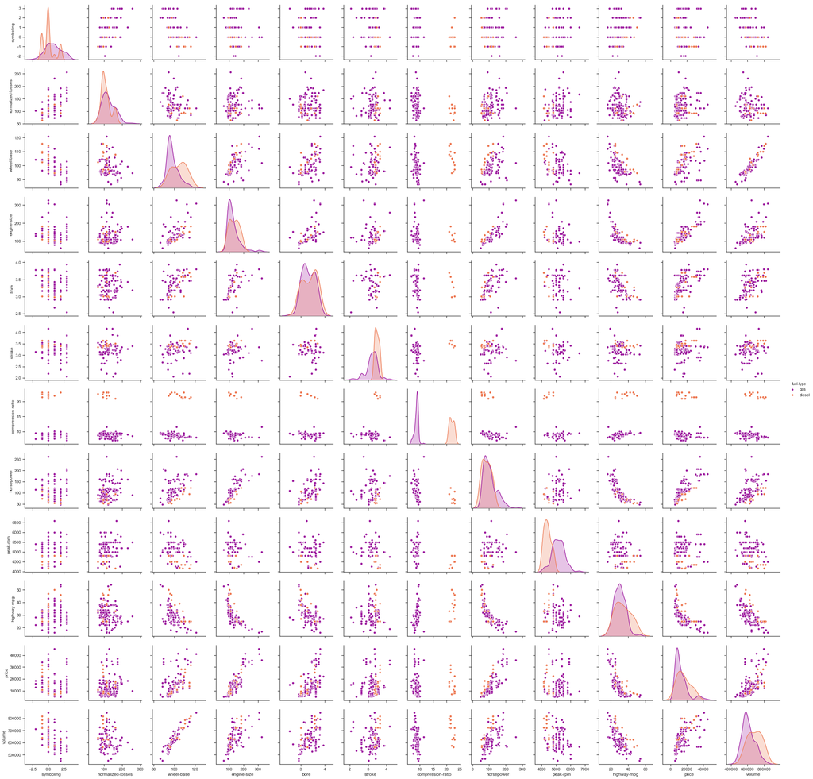

```python
sns.pairplot(data, hue = 'fuel-type', palette = 'plasma') # fuel-type有两种
```

观察价格和马力变量之间的关系

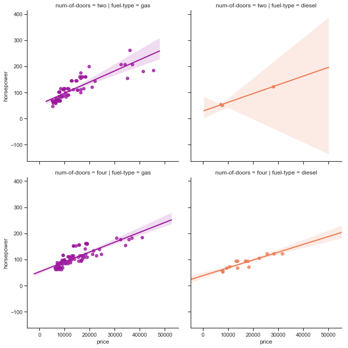

```python
sns.lmplot('price', 'horsepower', data,  # 横轴，纵轴，dataframe数据
           hue = 'fuel-type', col = 'fuel-type',  row = 'num-of-doors',
           # ↑列指定为烧油或者烧气(fuel-type)，行指定为门的数量(num-of-doors)
           palette = 'plasma',
           fit_reg = True);
```

事实上，对于燃料的类型和数门变量，可以观察到在一辆汽车马力的增加与价格成比例的增加相关的各个层面

### 预处理

如果一个特性的方差比其他的要大得多，那么它可能支配目标函数，使估计者不能像预期的那样正确地从其他特性中学习。这就是为什么需要首先对数据进行缩放。

- 对连续值进行标准化

```python
# target and features
target = data.price

regressors = [x for x in data.columns if x not in ['price']]
features = data.loc[:, regressors]

num = ['symboling', 'normalized-losses', 'volume', 'horsepower', 'wheel-base',
       'bore', 'stroke','compression-ratio', 'peak-rpm']

# scale the data
standard_scaler = StandardScaler()
features[num] = standard_scaler.fit_transform(features[num])

# glimpse
features.head()
```

|  | symboling | normalized-losses | make | fuel-type | aspiration | num-of-doors | body-style | drive-wheels | engine-location | wheel-base | ... | num-of-cylinders | engine-size | fuel-system | bore | stroke | compression-ratio | horsepower | peak-rpm | highway-mpg | volume |
| --- | --- | --- | --- | --- | --- | --- | --- | --- | --- | --- | --- | --- | --- | --- | --- | --- | --- | --- | --- | --- | --- |
| 0 | 1.78685 | 1.477685 | alfa-romero | gas | std | two | convertible | rwd | front | -1.682379 | ... | four | 130 | mpfi | 0.513027 | -1.808186 | -0.288273 | 0.198569 | -0.213359 | 27 | -1.168294 |
| 1 | 1.78685 | 1.477685 | alfa-romero | gas | std | two | convertible | rwd | front | -1.682379 | ... | four | 130 | mpfi | 0.513027 | -1.808186 | -0.288273 | 0.198569 | -0.213359 | 27 | -1.168294 |
| 2 | 0.16397 | 0.144710 | alfa-romero | gas | std | two | hatchback | rwd | front | -0.720911 | ... | six | 152 | mpfi | -2.394827 | 0.702918 | -0.288273 | 1.334283 | -0.213359 | 26 | -0.422041 |
| 3 | 0.97541 | 1.178276 | audi | gas | std | four | sedan | fwd | front | 0.142781 | ... | four | 109 | mpfi | -0.517605 | 0.480415 | -0.036204 | -0.039139 | 0.856208 | 30 | 0.169527 |
| 4 | 0.97541 | 1.178276 | audi | gas | std | four | sedan | 4wd | front | 0.077596 | ... | five | 136 | mpfi | -0.517605 | 0.480415 | -0.540341 | 0.304217 | 0.856208 | 22 | 0.193551 |

5 rows × 21 columns

- 对分类属性就行one-hot编码

```python
# categorical vars
classes = ['make', 'fuel-type', 'aspiration', 'num-of-doors',
           'body-style', 'drive-wheels', 'engine-location',
           'engine-type', 'num-of-cylinders', 'fuel-system']

# create new dataset with only continios vars
dummies = pd.get_dummies(features[classes])
features = features.join(dummies).drop(classes,
                                       axis = 1)

# new dataset
print('In total:', features.shape)
features.head()
```

```
In total: (193, 66)
```

|  | symboling | normalized-losses | wheel-base | engine-size | bore | stroke | compression-ratio | horsepower | peak-rpm | highway-mpg | ... | num-of-cylinders_six | num-of-cylinders_three | num-of-cylinders_twelve | fuel-system_1bbl | fuel-system_2bbl | fuel-system_idi | fuel-system_mfi | fuel-system_mpfi | fuel-system_spdi | fuel-system_spfi |
| --- | --- | --- | --- | --- | --- | --- | --- | --- | --- | --- | --- | --- | --- | --- | --- | --- | --- | --- | --- | --- | --- |
| 0 | 1.78685 | 1.477685 | -1.682379 | 130 | 0.513027 | -1.808186 | -0.288273 | 0.198569 | -0.213359 | 27 | ... | 0 | 0 | 0 | 0 | 0 | 0 | 0 | 1 | 0 | 0 |
| 1 | 1.78685 | 1.477685 | -1.682379 | 130 | 0.513027 | -1.808186 | -0.288273 | 0.198569 | -0.213359 | 27 | ... | 0 | 0 | 0 | 0 | 0 | 0 | 0 | 1 | 0 | 0 |
| 2 | 0.16397 | 0.144710 | -0.720911 | 152 | -2.394827 | 0.702918 | -0.288273 | 1.334283 | -0.213359 | 26 | ... | 1 | 0 | 0 | 0 | 0 | 0 | 0 | 1 | 0 | 0 |
| 3 | 0.97541 | 1.178276 | 0.142781 | 109 | -0.517605 | 0.480415 | -0.036204 | -0.039139 | 0.856208 | 30 | ... | 0 | 0 | 0 | 0 | 0 | 0 | 0 | 1 | 0 | 0 |
| 4 | 0.97541 | 1.178276 | 0.077596 | 136 | -0.517605 | 0.480415 | -0.540341 | 0.304217 | 0.856208 | 22 | ... | 0 | 0 | 0 | 0 | 0 | 0 | 0 | 1 | 0 | 0 |

5 rows × 66 columns

划分数据集

```python
# split the data into train/test set
X_train, X_test, y_train, y_test = train_test_split(features, target,  # X是features,y是target
                                                    test_size = 0.3,
                                                    random_state = seed)
print("Train", X_train.shape, "and test", X_test.shape)
```

```
Train (135, 66) and test (58, 66)
```

### Lasso回归

多加了一个绝对值项来惩罚过大的系数，alphas=0时就是最小二乘

```
CV results: 0.831966432169 342.008141897
```

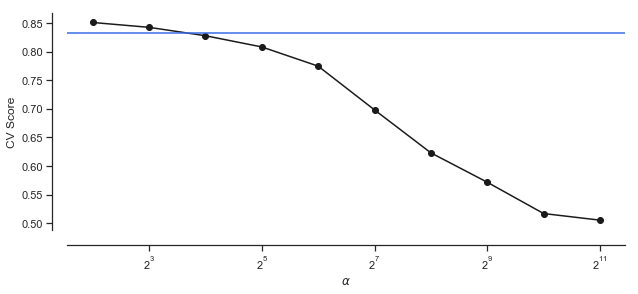

```python
# logarithmic scale: log base 2
# high values to zero-out more variables
alphas = 2. ** np.arange(2, 12)
scores = np.empty_like(alphas)

for i, a in enumerate(alphas):
    lasso = Lasso(random_state = seed)
    lasso.set_params(alpha = a)
    lasso.fit(X_train, y_train)
    scores[i] = lasso.score(X_test, y_test)

lassocv = LassoCV(cv = 10, random_state = seed)
lassocv.fit(features, target)
lassocv_score = lassocv.score(features, target)
lassocv_alpha = lassocv.alpha_ # 取出Lasso交叉验证后的alpha值

plt.figure(figsize = (10, 4))

plt.plot(alphas, scores, '-ko')
plt.axhline(lassocv_score, color = c)

plt.xlabel(r'$\alpha$')
plt.ylabel('CV Score')
plt.xscale('log', basex = 2)
sns.despine(offset = 15)

print('CV results:', lassocv_score, lassocv_alpha)
```

关于Score： [Sklearn官网关于Score的解释](http://scikit-learn.org/stable/modules/generated/sklearn.linear_model.Lasso.html#sklearn.linear_model.Lasso.score)

**Returns the coefficient of determination R^2 of the prediction.**

The coefficient R^2 is defined as (1 - u/v), where u is the residual sum of squares ((y_true - y_pred) **2).sum() and v is the total sum of squares ((y_true - y_true.mean())** 2).sum(). The best possible score is 1.0 and it can be negative (because the model can be arbitrarily worse). A constant model that always predicts the expected value of y, disregarding the input features, would get a R^2 score of 0.0.

It's already a good result: R squared of 0.83.

查看哪些特征对最终结果产生了正或负的影响（值越大影响越大）

```
Lasso picked 6 features and eliminated the other 60 features.
```

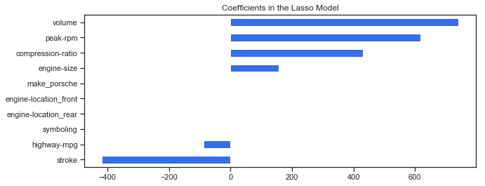

```python
# lassocv coefficients
coefs = pd.Series(lassocv.coef_, index = features.columns)

# 展示为0参数与非0参数的个数
print("Lasso picked " + str(sum(coefs != 0)) + " features and eliminated the other " +  \
      str(sum(coefs == 0)) + " features.")

# 排好序后选择前5个与后5个系数做展示
coefs = pd.concat([coefs.sort_values().head(5), coefs.sort_values().tail(5)])

plt.figure(figsize = (10, 4))
coefs.plot(kind = "barh", color = c)
plt.title("Coefficients in the Lasso Model")
plt.show()
```

```python
model_l1 = LassoCV(alphas = alphas, cv = 10, random_state = seed).fit(X_train, y_train)
y_pred_l1 = model_l1.predict(X_test)

model_l1.score(X_test, y_test)
```

```
0.82778582191511685
```

```python
print(model_l1.alpha_)
print(model_l1.coef_)
```

```
16.0
[  7.88567672e+01  -1.22492016e+02   5.24211032e+02   1.24271850e+02
  -5.84064453e+02  -1.55936009e+02   4.55769852e+00   5.48729905e+02
   8.21440991e+02   1.12923465e+02   1.26032690e+03   0.00000000e+00
   7.31033807e+02   5.61689502e+03   0.00000000e+00  -6.20492321e+02
  -0.00000000e+00   0.00000000e+00   0.00000000e+00   1.35906354e+02
   4.45170435e+03  -0.00000000e+00  -1.13359092e+03  -1.19262292e+03
  -1.16451289e+03  -1.42885036e+03   6.54962531e+03   1.08009184e+03
  -0.00000000e+00  -1.77222928e+03  -1.55209000e+02   0.00000000e+00
   0.00000000e+00  -0.00000000e+00  -2.01748752e+03   5.96563560e-11
   0.00000000e+00  -0.00000000e+00   3.36008684e+03   6.63368281e+02
  -4.20798354e+02  -0.00000000e+00  -8.58605219e+02   0.00000000e+00
  -1.70555184e+03   0.00000000e+00  -2.83609966e+03   0.00000000e+00
  -0.00000000e+00  -0.00000000e+00   2.85757951e+02   1.70609210e+01
  -2.28426504e+03   1.37809574e+03  -0.00000000e+00  -5.42382605e+02
   0.00000000e+00   0.00000000e+00  -0.00000000e+00  -1.28221502e+02
   4.72465222e+02   0.00000000e+00  -0.00000000e+00   9.28400159e+02
  -5.49313350e+01   0.00000000e+00]
```

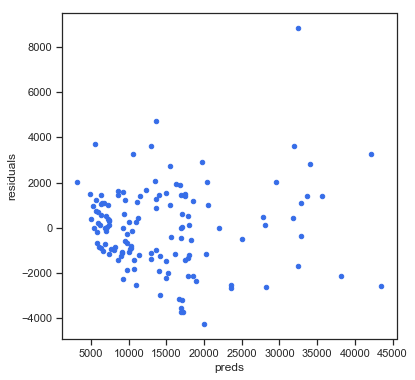

```python
# 查看预测值与真实值之间的差异
plt.rcParams['figure.figsize'] = (6.0, 6.0)

preds = pd.DataFrame({"preds": model_l1.predict(X_train), "true": y_train})
preds["residuals"] = preds["true"] - preds["preds"]
preds.plot(x = "preds", y = "residuals", kind = "scatter", color = c)
```

```python
# from sklearn.metrics import mean_squared_error, r2_score
def MSE(y_true,y_pred):
    mse = mean_squared_error(y_true, y_pred)
    print('MSE: %2.3f' % mse)
    return mse

def R2(y_true,y_pred):
    r2 = r2_score(y_true, y_pred)
    print('R2: %2.3f' % r2)
    return r2

MSE(y_test, y_pred_l1); R2(y_test, y_pred_l1);
```

```
MSE: 3993172.564
R2: 0.828
```

```python
# predictions
d = {'true' : list(y_test),
     'predicted' : pd.Series(y_pred_l1)
    }

pd.DataFrame(d).head()
```

|  | predicted | true |
| --- | --- | --- |
| 0 | 8503.836069 | 8499.0 |
| 1 | 17137.224283 | 17450.0 |
| 2 | 8511.911025 | 9279.0 |
| 3 | 10935.968247 | 7975.0 |
| 4 | 6233.718975 | 6692.0 |